# 2016-02-22-Spark-Cluster-Setup-on-VirtualBox

In an [earlier post](http://jaehyeon-kim.github.io/r/2015/11/28/Connecting-to-VirtualBox-Guest-via-SSH-And-RStudio-Server/), a way to connect an Ubuntu guest to a Windows host on VirtualBox is introduced as well as RStudio server is set up. This article is an extension of the post, which demonstrates how to set up a Spark cluser between 2 Ubuntu guests. Firstly it begins with machine preparation. Once a machine is baked, its image file (*VDI*) can be copied for the second one. Then how to launch a cluster by [standalone mode](http://spark.apache.org/docs/latest/spark-standalone.html) is discussed. Let’s get started.

#### Machine preparation

If you haven’t read the previous post, I recommend to read as it introduces [Putty](http://www.chiark.greenend.org.uk/~sgtatham/putty/download.html) as well. Also, as Spark need Java Development Kit (JDK), you may need to *apt-get* it first - see [this tutorial](https://www.digitalocean.com/community/tutorials/how-to-install-java-on-ubuntu-with-apt-get) for further details.

I downloaded *Spark 1.6.0 Pre-built for Hadoop 2.6 and later* and unpacked it in my user directory as following.

```
cd ~
wget http://www.us.apache.org/dist/spark/spark-1.6.0/spark-1.6.0-bin-hadoop2.6.tgz
tar zxvf spark-*.tgz
mv ./spark*/ spark
```

Then I prepared ‘*password-less*’ SSH access (no passphrase) from the master machine to the other by generating a ssh key.

```
mkdir .ssh
ssh-keygen -t rsa
Enter file in which to save the key (/home/you/.ssh/id_rsa): [ENTER]
Enter passphrase (empty for no passphrase): [EMPTY]
Enter same passphrase again: [EMPTY]
```

You will see two files *id_rsa* (private key) and *id_rsa.pub* (public key) in *.ssh* folder. The public key was added to a file called *authorized_keys* as following.

```
cd .ssh
cat id_rsa.pub >> authorized_keys
chmod 644 authorized_keys
```

Note that, by now, there is only a single machine but its image file will be copied shortly to be used as a slave machine. Therefore adding a public key to the *authorized_keys* file will be convenient.

#### Set up guest machines

I named the baked machine’s image file as *spark-master.vdi* and copied it as *spark-slave.vdi*. When I tried to create a virtual machine with the new image, the following error was encountered, which indicates duplicate UUIDs.

[figure not shown]

This was resolved by setting a differnet UUID using *VBOXMANAGE.EXE*. On my Windows (host) CMD, I did the following and it was possible to create a virtual machine from the copied image.

```
cd "C:\Program Files\Oracle\VirtualBox"
VBOXMANAGE.EXE internalcommands sethduuid "D:\VirtualEnv\spark-slave.vdi"
```

As in the previous post, I set up 2 network adapters - Bridged Adapter and Host-only Adapter. The latter lets a virtual machine to have a static IP. As the second image is copied from the first, both have the same IP address, which can be problematic. They can have different IP addresses by letting them have different MAC addresses. (Note the refresh button in the right.)

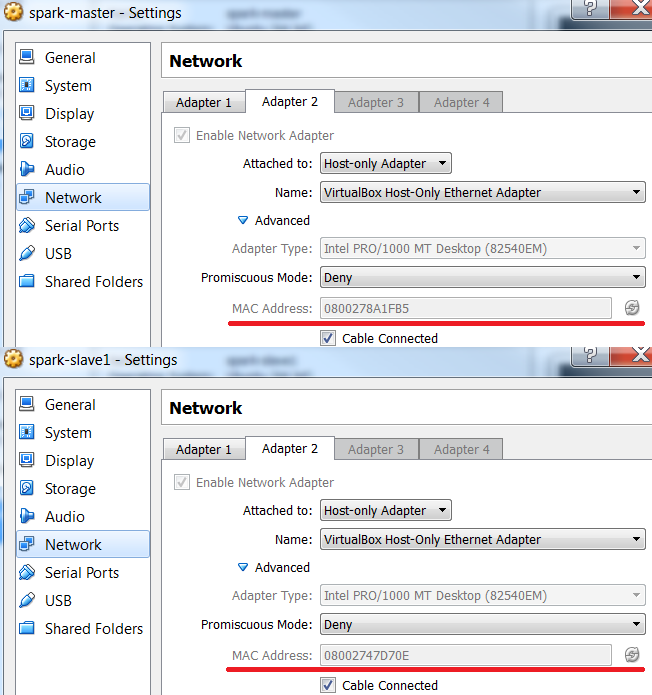

In my case, the master and slave machine’s IP addresses are set up to be *192.168.1.8* and *192.168.1.11*.

[figure not shown]

Also they have the same host name: *ubuntu-master*. It’d be necessary to change the slave machine’s host name. I modified the host name in */etc/hostname* and */etc/hosts*. Basically I changed any *ubuntu-master* in those files to *ubuntu-slave1* and restarted the machine - see further [details](http://askubuntu.com/questions/87665/how-do-i-change-the-hostname-without-a-restart) Note this requires **root** privilege.

The updated host name is shown below in the right.

[figure not shown]

Finally I added slave’s host information to the master’s */etc/hosts* and did the other way around to the slave’s file.

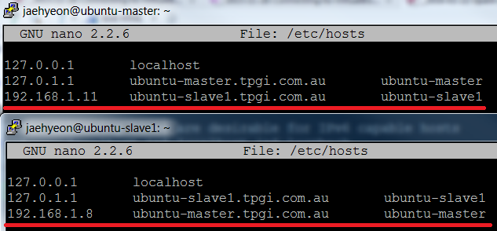

#### Standalone mode setup

Firstly I added the slave machine’s host name to the master’s *slaves* file in *~/spark/conf* as following.

```
cd ~/spark/conf/
cp slaves.template slaves
```

I just commented *localhost*, which is in the last line and added the slave’s host name. i.e.

```
#localhost
ubuntu-slave1
```

Then I updated *spark-env.sh* file on each of the machines.

```
cp spark-env.sh.template spark-env.sh
```

And, for the master, I added the following

```
JAVA_HOME=/usr/lib/jvm/java-7-openjdk-amd64
export SPARK_MASTER_IP=192.168.1.8
export SPARK_WORKER_CORES=1
export SPARK_WORKER_INSTANCES=1
export SPARK_MASTER_PORT=7077
export SPARK_WORKER_MEMORY=4g
export MASTER=spark://${SPARK_MASTER_IP}:${SPARK_MASTER_PORT}
export SPARK_LOCAL_IP=192.168.1.8
```

and, for the slave,

```
JAVA_HOME=/usr/lib/jvm/java-7-openjdk-amd64
export SPARK_MASTER_IP=192.168.1.8
export SPARK_WORKER_CORES=1
export SPARK_WORKER_INSTANCES=1
export SPARK_MASTER_PORT=7077
export SPARK_WORKER_MEMORY=4g
export MASTER=spark://${SPARK_MASTER_IP}:${SPARK_MASTER_PORT}
export SPARK_LOCAL_IP=192.168.1.11
```

That’s it. By executing the following command, I was able to create a Spark cluster and to check the status of the cluster in the web UI.

```
~/spark/sbin/start-all.sh
```

[figure not shown]

I hope this post is useful.